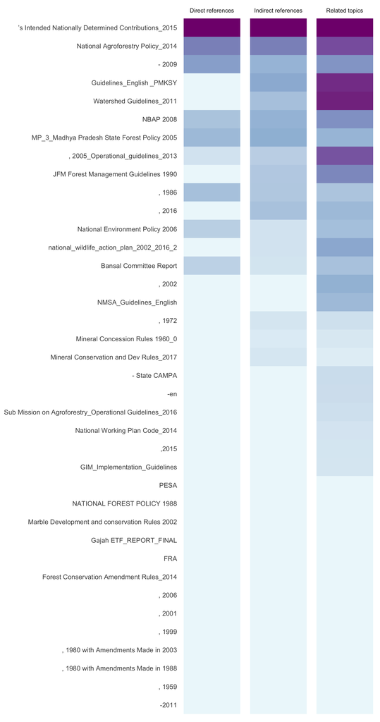

**- 2009**

**, 1972**

1. E.grants and loans to authority and constitution of fund.1 the central government may, after due appropriation made by parliament by law in this behalf, make to the authority grants and loans of such sums of money as that government may consider necessary. **25**

**, 1986**

1. Maintenance of and operation upon bank account investment of the corporation.– **128**
2. , the agricultural re-finance corporation established under the agricultural re- **186**
3. Power to make grants or loans for construction of private irrigation works. **43**
4. With the prior approval of the state government issue and sell bonds and debentures, and other securities carrying interest;borrow money and accept deposits from central government, the state government, any bank or financial institution and with the approval of the state government, from a corporate body or from any other person. **418**
5. Any funds of the corporation not required for current expenditure may be placed in fixed deposits with the reserve bank of india, state bank of india or any scheduled or cooperative bank approved in this behalf by the state government or invested in the name of the corporation in the securities of the state government or the central government. **129**
6. There shall be formed for each irrigation panchayat a fund to be called the irrigation panchayat fund, and the money recovered by way of composition under this rule shall be placed to the credit of this fund. **84**
7. Establishment and management of provident fund or other benefit funds forgenerally for the efficient conduct of the affairs of the nigam. **426**
8. Whereas it is expedient to encourage the establishment of warehouses for storing agricultural produce and to make provision for their proper supervision and control; it is hereby enacted as follows 1 the main problem of agricultural credit in india is how to make adequate short-term finance available to the agriculturist at a reasonable rate of interest. In view of the special responsibility placed on the reserve bank of india in regard to agricultural credit, the bank has been anxious to make within the scope of the reserve bank of india act, credit more extensively available to agriculturists on reasonable terms. Section 174d of the reserve bank of india act provide that the reserve bank may make loans and advances repayable on demand or on the expiry of fixed periods not exceeding ninety days against security of promissory note of any schedule banks or provincial co-operative bank supported by documents of title to goods which have been transferred, assigned or pledged to any such banks as security for cash credit or overdraft granted for bona fide commercial or trade transactions or for the purpose of financing seasonal operations on the marketing of crops. **118**

**, 2005_Operational_guidelines_2013**

1. For funds for technical & managerial expertise central state finance commission grants programme staff for implementation of any of the schemes shown on the left national rural livelihood missioner integrated watershed management programme wimp total sanitation programme TSC backward region grant fund brag ashtray krishi visas yojana york err ministry of water resources national afforestation programme nap prada mantra grain sadat yojanapmgsy national horticulture mission ohm schemes funded from state budget 15.2.1 some illustrations of existing arrangements for convergence between and other schemes are shown in annexure. 36 **140**
2. 2 the state government should be responsible for ensuring efficient fund management not only at the state level, but also at the district pia level. Funds from segf will be released to the districts only if the fund recipient agencies fulfill the pre-conditions as prescribed by the central government. **108**
3. For this a cascading network of capacity building institutions needs to be created. States should assess requirements of funds for capacity building and consider earmarking funds for capacity building from the administrative expense head. **47**
4. Fund 12.3.1 sub-section 1 of section 21 of provides for the establishment of state employment guarantee fund segf also referred to as state fund for the purpose of implementation of the scheme in an implementing state. In exercise of the powers conferred under clauseof subsection 2 of section 32 of 2005, the state governments need to notify employment guarantee fund rules proposing constitution of an segf and indicating a comprehensive framework to effectively manage the receipt, transfer and utilisation of financial resources under through this segf. The states are also required to design mechanisms within the segf rules to ensure transparency, efficiency and accountability. The segf should have an in-built capacity to track the usage of funds down to the gps. The central share of funds are released to segf for onward allocation of funds to the districtspanchayatsprogramme implementing agencies pias of the respective state. The segf is expended and administered as per state government notified fund governance rules in accordance with the provisions of . The salient features of the segf are explained in box 13.2.segf funds shall be utilised in accordance with the provisions of the act and rules framed there under by the central government and instructions issued by ministry of rural development from time to time.segf pools resources from centre central share and state state share and cause its deployment within the districts as per their fund requirements. Interest accruing on account of funds should be a part of the segf and shall be spent only in accordance with instructions of the central government.the segf shall ensure district-wise effective fund management under . The agency designated for fund management in a state should have a status different from the state government. Generally, the state funds are managed by self-regulating societies registered under the societies registration act. **108**

**, 2016**

1. State authority may invest funds available in the state fund of such state in the securities of the central government and in scheduled banks in such manner as may be prescribed provided that the grants received from the state government shall not be invested and shall be utilised for the purpose and in the manner prescribed. **14**
2. The national authority may invest its funds, including any reserve fund, in the securities of the central government and in scheduled banks in such manner as may be prescribed provided that the grants received from the central government shall not be invested and shall be utilised for the purposes and in the manner attached to it. **13**

**National Agroforestry Policy_2014**

1. Institutional finance and insurance coverage institutional finance in agroforestry has not been at par with its potential due to the lack of awareness of technical and economic data on different agroforestry models, and the techno-economic parameters required by financial institutions phi to evaluate finance needs and viability of the projects. Similarly, little is done in developing and popularizing insurance products for agroforestry ventures. Lack of awareness, unavailability of products suitable to growers, high cost of premium and unclear procedure of claim settlements are reported to be the factors responsible for this poor state of affairs. **5**
2. Establishment of institutional setup at national level to promote agroforestry 5.1.1 an institutional mechanism, such as a mission or board is to be established for implementing the agroforestry policy. It will provide the platform for the multi-stakeholders to jointly plan and identify the priorities and strategies, for inter-ministerial coordination, programmatic convergence, financial resources mobilization and leveraging, capacity building facilitation, and technical and management support. Such an institutional arrangement will ensure that agroforestry gets equal treatment with other agriculture enterprises, because at present whether in the sphere of inputs, markets, institutional finance, or research and extension, agroforestry is at a sub-optimal level. A suitable mechanism for coordination and convergence with state agriculture, and forest departments as nodal agencies may be established. The mission board may be provided a corpus in order to effectively leverage rs. 4000-5000 crores annually from the on-going programmes. **7**
3. Specific products special purpose vehicles may be devised to meet the credit and insurance needs of agroforestry sector. Interest subvention in the line of agricultural credit be extended to agroforestry sector. Agroforestry commodities also be enlisted under warehouse development and regulation act 2007 ward for ensuring adoption of quality standards of the warehousing manual for operationalizing of warehousing development and regulation act, 2007 so as to become eligible for availing finance for harvested produce of agroforestry. **14**
4. There is need for setting up of special purpose vehicles banking institutions to address specific needs of agroforestry sector. Agroforestry sector should also be benefited with the provisions of interest subvention in the line of agricultural credit. Dedicated farmers producers organizations fpo be promoted to organize the farmers and take up agroforestry at economies of scale. **11**

**National Environment Policy 2006**

1. The following will comprise elements of an action plan a encourage capacity building in the financial sector for appraising clean technology switchover projectset up a mechanism to network technology research institutions in the country, public and private, for cooperation in technology research and development and adaptation, information, and evaluation of clean technologies. Create a database of such technologies, and promote dissemination of new technologiesconsider use of revenue enhancing fiscal instruments to promote shifts to clean technologies in both existingpromote adoption of clean technologies by industry, in particular in the small and medium sector, through regulatory and fiscal measures, and standards setting. **51**

**Watershed Guidelines_2011**

1. From the budget of the respective department ministry after suitable review of the existing staff and infrastructure already available and actual requirement. It may also receive support from other institutes and agencies both national and international, corporate entities, and such other organisations which seek to support programmes on watershed mode. **20**
2. This team will be selected by the state level nodal agency either on deputation from experts available from the line departments or in case such experts are not available, they may be engaged on contract basis from the open market by a transparent process. Their disciplines will, inter-alia, include agriculture, water management, capacity building, social mobilisation, information technology, administration and finance accounts, etc. A requisite number of administrative staff will support this team of experts. **22**

**’s Intended Nationally Determined Contributions_2015**

1. To achieve about 40 percent cumulative electric power installed capacity from non fossil fuel based energy resources by 2030 with the help of transfer of technology and low cost international finance including from green climate fund gcf. **29**
2. Maximum share of india's current climate finance comes from budgetary sources, as most of the resources for adaptation and mitigation are built into the ongoing sectoral programmes. **26**
3. Introduction of tax free infrastructure bonds for funding of renewable energy projects. **37**
4. New ventures india vi is an initiative to support clean tech entrepreneurs in developing their business plans and access finance and markets. **19**
5. To mobilize domestic and new & additional funds from developed countries to implement the above mitigation and adaptation actions in view of the resource required and the resource gap. **29**
6. At the same time india is not relying solely on budgetary resources and is experimenting with a careful mix of market mechanisms together with fiscal instruments and regulatory interventions to mobilize finance for climate change. **26**
7. Over the years, the carbon intensity of the indian economy has decreased, in large part, due to the adoption of new and innovative technologies which address climate mitigation and climate adaptation. The development, adoption and dissemination of these technologies has been an ongoing process which has led to, inter-alia, increased energy efficiency and an increasing share of renewable in the electricity grid. This has been facilitated by several bilateral and multilateral collaborative efforts both in the public and private sector. **28**
8. Governments salary budget would be required for capacity building initiatives, while some part of it would need to be financed internationally. **32**
9. India has set up a national adaptation fund with an initial allocation of int 3,500 million usd 55.6 million to combat the adaptation needs in sectors like agriculture, water, forestry etc. In addition to sectoral spending by the respective ministries. **27**
10. Tax free infrastructure bonds of int 50 billion usd 794 million are being introduced for funding of renewable energy projects during the year 2015-16. **27**

**Bansal Committee Report**

1. Ix financial support banking support through facilitating easy access to credit for eligible farmers and rationalization of cumbersome and lengthy procedures for sanction and disbursement of bank loans for agro forestry plantations. **32**

**Guidelines_English _PMKSY**

1. Coordinating preparation of dips and sip; ii coordinating preparation and appraisal of projects, implementing, monitoring, and evaluation with various departments and implementing agencies. Iii management of funds received from the central, and state governments and disbursement of the funds to the implementing agencies. **10**
2. Central assistance under pmksy will be released as per extant guidelines of the ministry of finance, govt. Of india. **16**
3. Pmksy funds will be provided to the state governments as per the pattern of assistance of centrally sponsored schemes decided by ministry of finance and nit aayog. During 2015-16, existing pattern of assistance of ongoing schemes will be continued. **8**

**JFM Forest Management Guidelines 1990**

1. Profits from forest go to FPS do shrank voluntary labour and contribute to village common fund building a common fund maintenance of money in a bank account full rights of collection and marketing of NTFPS village assets improved **41**
2. All the income that accrues to the —————————— name of the group from interest on savings, interest on loans, including the emergency fund plus returns from penalties and fees will be re-invested in the —————————— name of the group fund. **85**
3. Opening savings bank account with bank.enabling SHG members to obtain loans from banks,and repaying the same. **51**
4. Arrange necessary funds required for expenditure from the forest department and other departments organizations. **69**

**Mineral Concession Rules 1960_0**

1. A bank specified in column 2 of the first schedule to the banking companies 3. A finance corporation owned and controlled by a state government. **148**

**Mineral Conservation and Dev Rules_2017**

1. # indicate the names of the lending institutions such as state finance corporation, industrial development and other public corporations, co-operative banks, nationalised banks and other sources along with the amount of loan from each source and the rate of interest at which loan hasinterest paid during the year ii rents excluding surface rent paid during the year 1. Quantity and cost of material consumed during the year iv explosives furnish full details in part iv **104**

**MP_3_Madhya Pradesh State Forest Policy 2005**

1. In order to make soft loans available for intensive forestry works in suitable areas, 'madhya pradesh forest finance corporation' will be established with the cooperation of central and state government. **26**
2. With the objective of providing the state proportionate resources at the national level, it is necessary to introduce the system of natural resource accounting, so that efforts could be made to provide resources for forest conservation and management matching the contribution of direct and indirect benefits of the forests in the gross domestic product. Moreover, to mobilize financial and other resources it is also necessary to encourage private investment and also mobilize resources from other sources, such as environment tax, water tax, external grants, loans, etc. It is also necessary to attract private investment to augment the productivity of the most degraded government forests. **3**
3. Suitable efforts shall be made to seek financial assistance from the national and the international institutions. **26**
4. In order to obtain funds from private individuals organisations for development of forests of the state, green madhya pradesh fund will be established. Efforts will be made to get introduced provision of income tax exemption on contribution towards this fund by private individuals organisations. **26**
5. Attracting private investment for the afforestation work on a large scale in the forestry sector. **6**

**national_wildlife_action_plan_2002_2016_2**

1. Priority projects 1.1 initiate briefing sessions discussions with members of parliament, various ministries, the prime minister and his office, the planning commission, the national development council and the committee of secretaries, either individually or collectively, on the economic importance of protecting and sustainably using, not over-exploiting, our natural treasury. Similarly, briefing sessions should be held with chief ministers, finance ministers, home ministers and agriculture ministers of statesuts. Timing to start in 2002 and ongoing. Responsibility moef. 1.2 state wildlife wings will carry out similar briefing discussions with panchayat raj institutions and other grassroots level institutions involved in the field of rural development. Timing to start in 2002 and ongoing. Responsibility states and uts. 1.3 preparation of a report accessing policies and action plans of other related ministries to provide guidelines for the planning commission, which would help to harmonise other sectoral activities outside pas. Timing to start in 2002 and ongoing. Responsibility moef, planning commission, state governments and scientific institutions. **40**

**NBAP 2008**

1. Develop projects for accessing funds for conservation and sustainable use of biodiversity from external sources, earmarked for conservation through bilateral, regional and other multilateral channels. **64**
2. To ensure higher resource flows, comprising finance, technology management skills, traditional knowledge, and social capital, for biodiversity conservation through mutually beneficial stakeholder partnerships between local communities, public agencies, the academic and research community, investors, and multilateral and bilateral development partners. **32**
3. Promote entrepreneurship development, public private partnership particularly in agro - food processing, self help groups and wadding workers for undertaking village based activities and micro-financing. **59**
4. To factor in natural resource accounting nra in the national economic planning processes and encourage financial institutions to adopt appropriate nra appraisal practices so that risks to biological diversity are adequately considered in the financing of projects. **33**
5. Encourage adoption of science-based, and traditional sustainable land use practices, through research and development, extension of knowledge, pilot scale demonstrations, and large scale dissemination including farmer's training, and where necessary, access to institutional finance. **47**
6. Since many of the activities envisioned in the nbap are ongoing, these would be taken up and mainstreamed under the ambit of existing schemes and programmes by the central and state governments, public and private sector as well as civil society organizations, securing full utilization of available infrastructure and funds, with marginal to substantial augmentation and further inputs, wherever required. In addition, sources of external funding would also be explored and availed of, in accordance with the extant policies and regulations. Thus, no separate scheme or allocation for implementation of nbap is envisaged. **65**